# Linear Regression – Class Assessment

# here we found that "Weight" ,"length1" ,"length2" and "length3" have some outliers we have to fix it.

```python
# lets use IQR Method to find out outlier.
Q1 = fish.quantile(0.25)
Q3 = fish.quantile(0.75)
IQR = Q3 - Q1
print(IQR) # Here we got the IQR Of each coloumn so lets use it for next opration.
```

```
Weight     527.50000
Length1     13.65000
Length2     14.50000
Length3     16.50000
Height       6.42110
Width        2.19885
dtype: float64
```

```python
# Lets find out outlier in datasets.
outlier = (fish < (Q1 - 1.5 * IQR)) | (fish > (Q3 + 1.5 * IQR))
```

```python
outlier[outlier.Weight==True] # Here we found that there is a outlier in Wieght at index of 142,143,144.
```

|  | Height | Length1 | Length2 | Length3 | Species | Weight | Width |
| --- | --- | --- | --- | --- | --- | --- | --- |
| 144 | False | True | True | True | False | True | False |
| 142 | False | True | True | False | False | True | False |
| 143 | False | True | True | False | False | True | False |

```python
outlier[outlier.Length1==True] # Here we found that there is a outlier in Length1 at index of 142,143,144.
```

|  | Height | Length1 | Length2 | Length3 | Species | Weight | Width |
| --- | --- | --- | --- | --- | --- | --- | --- |
| 144 | False | True | True | True | False | True | False |
| 142 | False | True | True | False | False | True | False |
| 143 | False | True | True | False | False | True | False |

```python
outlier[outlier.Height==True] # No any outliers
```

|  | Height | Length1 | Length2 | Length3 | Species | Weight | Width |
| --- | --- | --- | --- | --- | --- | --- | --- |

```python
outlier[outlier.Length2==True] # Here we found that there is a outlier in Length2 at index of 142,143,144.
```

|  | Height | Length1 | Length2 | Length3 | Species | Weight | Width |
| --- | --- | --- | --- | --- | --- | --- | --- |
| 144 | False | True | True | True | False | True | False |
| 142 | False | True | True | False | False | True | False |
| 143 | False | True | True | False | False | True | False |

```python
outlier[outlier.Length3==True] # Here we found that there is a outlier in Length3 at index of 144.
```

|  | Height | Length1 | Length2 | Length3 | Species | Weight | Width |
| --- | --- | --- | --- | --- | --- | --- | --- |
| 144 | False | True | True | True | False | True | False |

```python
outlier[outlier.Width==True] # No any outlier
```

|  | Height | Length1 | Length2 | Length3 | Species | Weight | Width |
| --- | --- | --- | --- | --- | --- | --- | --- |

Here we have to decide that we want to impute it or remove it .

give in description -->Identify outliers and remove if any

```python
# calculate the outlier cutoff
cut_off = IQR * 1.5
lower = Q1 - cut_off
upper = Q3 + cut_off
```

```python
lower
```

```
Weight    -668.750000
Length1     -1.425000
Length2     -0.750000
Length3     -1.600000
Height      -3.686850
Width        0.087375
dtype: float64
```

```python
upper
```

```
Weight     1441.250000
Length1      53.175000
Length2      57.250000
Length3      64.400000
Height       21.997550
Width         8.882775
dtype: float64
```

```python
cols
```

```
['Weight', 'Length1', 'Length2', 'Length3', 'Height', 'Width']
```

```python
# lets remove the outliers from the data
new_fish = fish[~((fish < (Q1 - 1.5 * IQR)) | (fish > (Q3 + 1.5 * IQR))).any(axis=1)]
```

```python
#lets Verify the data
new_fish.shape # here we see that the outlier is removed from the data set and we we remaining data.
```

```
(156, 7)
```

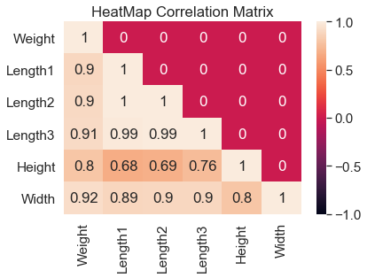

```python
# we have to check the multicolinearity in data.
# Checking for Multicolinearity.
# Correlation Matrix take only the lower triangle
cor = new_fish[cols].corr()
cor = np.tril(cor)
sns.heatmap(cor , xticklabels = cols , yticklabels = cols ,
 vmin = -1 , vmax = 1 , annot=True , square = False)
plt.title('HeatMap Correlation Matrix')
```

here we found that our Y variable is highly corelated with X-variables

which is good for us, but length3 is highly corelated with length2 , length1 and width .

So , we can drop the Length3 .

```python
#split the columns into nc and fc
fc=new_fish.select_dtypes(include='object').columns.values

nc=new_fish.select_dtypes(exclude='object').columns.values
```

```python
fc
```

```
array(['Species'], dtype=object)
```

```python
nc
```

```
array(['Weight', 'Length1', 'Length2', 'Length3', 'Height', 'Width'],
      dtype=object)
```

```python
# We have to use one hot encoding for handle the factor variable coz it required numeric data for linear regression model.
dummy=pd.get_dummies(new_fish.Species,drop_first=True,prefix='Species')
new_fish= new_fish.join(dummy)
```

```python
new_fish.head(10)
```

|  | Species | Weight | Length1 | Length2 | Length3 | Height | Width | Species_Parkki | Species_Perch | Species_Pike | Species_Roach | Species_Smelt | Species_Whitefish |
| --- | --- | --- | --- | --- | --- | --- | --- | --- | --- | --- | --- | --- | --- |
| 65 | Parkki | 150.0 | 18.4 | 20.0 | 22.4 | 8.8928 | 3.2928 | 1 | 0 | 0 | 0 | 0 | 0 |
| 1 | Bream | 290.0 | 24.0 | 26.3 | 31.2 | 12.4800 | 4.3056 | 0 | 0 | 0 | 0 | 0 | 0 |
| 61 | Parkki | 55.0 | 13.5 | 14.7 | 16.5 | 6.8475 | 2.3265 | 1 | 0 | 0 | 0 | 0 | 0 |
| 74 | Perch | 40.0 | 13.8 | 15.0 | 16.0 | 3.8240 | 2.4320 | 0 | 1 | 0 | 0 | 0 | 0 |
| 18 | Bream | 610.0 | 30.9 | 33.5 | 38.6 | 15.6330 | 5.1338 | 0 | 0 | 0 | 0 | 0 | 0 |
| 93 | Perch | 145.0 | 20.7 | 22.7 | 24.2 | 5.9532 | 3.6300 | 0 | 1 | 0 | 0 | 0 | 0 |
| 92 | Perch | 150.0 | 20.5 | 22.5 | 24.0 | 6.7920 | 3.6240 | 0 | 1 | 0 | 0 | 0 | 0 |
| 9 | Bream | 500.0 | 28.5 | 30.7 | 36.2 | 14.2266 | 4.9594 | 0 | 0 | 0 | 0 | 0 | 0 |
| 116 | Perch | 900.0 | 36.5 | 39.0 | 41.4 | 11.1366 | 7.4934 | 0 | 1 | 0 | 0 | 0 | 0 |
| 54 | Roach | 390.0 | 29.5 | 31.7 | 35.0 | 9.4850 | 5.3550 | 0 | 0 | 0 | 1 | 0 | 0 |

```python
# Now drop the original column from dataset
new_fish = new_fish.drop('Species' , axis = 1)
```

```python
# Verify the result
new_fish
```

|  | Weight | Length1 | Length2 | Length3 | Height | Width | Species_Parkki | Species_Perch | Species_Pike | Species_Roach | Species_Smelt | Species_Whitefish |
| --- | --- | --- | --- | --- | --- | --- | --- | --- | --- | --- | --- | --- |
| 65 | 150.0 | 18.4 | 20.0 | 22.4 | 8.8928 | 3.2928 | 1 | 0 | 0 | 0 | 0 | 0 |
| 1 | 290.0 | 24.0 | 26.3 | 31.2 | 12.4800 | 4.3056 | 0 | 0 | 0 | 0 | 0 | 0 |
| 61 | 55.0 | 13.5 | 14.7 | 16.5 | 6.8475 | 2.3265 | 1 | 0 | 0 | 0 | 0 | 0 |
| 74 | 40.0 | 13.8 | 15.0 | 16.0 | 3.8240 | 2.4320 | 0 | 1 | 0 | 0 | 0 | 0 |
| 18 | 610.0 | 30.9 | 33.5 | 38.6 | 15.6330 | 5.1338 | 0 | 0 | 0 | 0 | 0 | 0 |
| ... | ... | ... | ... | ... | ... | ... | ... | ... | ... | ... | ... | ... |
| 72 | 5.9 | 7.5 | 8.4 | 8.8 | 2.1120 | 1.4080 | 0 | 1 | 0 | 0 | 0 | 0 |
| 150 | 8.7 | 10.8 | 11.3 | 12.6 | 1.9782 | 1.2852 | 0 | 0 | 0 | 0 | 1 | 0 |
| 46 | 140.0 | 21.0 | 22.5 | 25.0 | 6.5500 | 3.3250 | 0 | 0 | 0 | 1 | 0 | 0 |
| 69 | 200.0 | 21.2 | 23.0 | 25.8 | 10.3458 | 3.6636 | 1 | 0 | 0 | 0 | 0 | 0 |
| 50 | 200.0 | 22.1 | 23.5 | 26.8 | 7.3968 | 4.1272 | 0 | 0 | 0 | 1 | 0 | 0 |

156 rows × 12 columns

```python
# Check the data type of dataset to verify that the dataset have all the numeric variable
new_fish.dtypes
```

```
Weight               float64
Length1              float64
Length2              float64
Length3              float64
Height               float64
Width                float64
Species_Parkki         uint8
Species_Perch          uint8
Species_Pike           uint8
Species_Roach          uint8
Species_Smelt          uint8
Species_Whitefish      uint8
dtype: object
```

```python
# CHeck some stat.
new_fish.describe(include = 'all')
```

|  | Weight | Length1 | Length2 | Length3 | Height | Width | Species_Parkki | Species_Perch | Species_Pike | Species_Roach | Species_Smelt | Species_Whitefish |
| --- | --- | --- | --- | --- | --- | --- | --- | --- | --- | --- | --- | --- |
| count | 156.000000 | 156.000000 | 156.000000 | 156.000000 | 156.000000 | 156.000000 | 156.000000 | 156.000000 | 156.000000 | 156.000000 | 156.000000 | 156.000000 |
| mean | 376.191987 | 25.655769 | 27.786538 | 30.571154 | 8.951128 | 4.375719 | 0.070513 | 0.358974 | 0.089744 | 0.128205 | 0.089744 | 0.038462 |
| std | 318.625672 | 9.119630 | 9.792651 | 10.695359 | 4.324325 | 1.672188 | 0.256834 | 0.481245 | 0.286735 | 0.335395 | 0.286735 | 0.192927 |
| min | 5.900000 | 7.500000 | 8.400000 | 8.800000 | 1.728400 | 1.047600 | 0.000000 | 0.000000 | 0.000000 | 0.000000 | 0.000000 | 0.000000 |
| 25% | 120.000000 | 19.000000 | 21.000000 | 23.025000 | 5.931675 | 3.369600 | 0.000000 | 0.000000 | 0.000000 | 0.000000 | 0.000000 | 0.000000 |
| 50% | 271.000000 | 25.000000 | 26.750000 | 29.250000 | 7.647800 | 4.243300 | 0.000000 | 0.000000 | 0.000000 | 0.000000 | 0.000000 | 0.000000 |
| 75% | 612.500000 | 32.125000 | 35.000000 | 39.425000 | 12.378550 | 5.424375 | 0.000000 | 1.000000 | 0.000000 | 0.000000 | 0.000000 | 0.000000 |
| max | 1250.000000 | 52.000000 | 56.000000 | 59.700000 | 18.957000 | 8.142000 | 1.000000 | 1.000000 | 1.000000 | 1.000000 | 1.000000 | 1.000000 |

Q.3 Build a regression model and print regression equation?

```python
# Now Split the data int train and test
trainx ,testx , trainy , testy = train_test_split(new_fish.drop('Weight' , axis=1),new_fish["Weight"] , test_size=0.15)
```

```python
print("trainx={},trainy={},testx={},testy ={}".format(trainx.shape,trainy.shape,testx.shape,testy.shape))
```

```
trainx=(132, 11),trainy=(132,),testx=(24, 11),testy =(24,)
```

Build the Regression Model by using OLS

```python
trainx
```

|  | Length1 | Length2 | Length3 | Height | Width | Species_Parkki | Species_Perch | Species_Pike | Species_Roach | Species_Smelt | Species_Whitefish |
| --- | --- | --- | --- | --- | --- | --- | --- | --- | --- | --- | --- |
| 50 | 22.1 | 23.5 | 26.8 | 7.3968 | 4.1272 | 0 | 0 | 0 | 1 | 0 | 0 |
| 46 | 21.0 | 22.5 | 25.0 | 6.5500 | 3.3250 | 0 | 0 | 0 | 1 | 0 | 0 |
| 94 | 21.0 | 23.0 | 24.5 | 5.2185 | 3.6260 | 0 | 1 | 0 | 0 | 0 | 0 |
| 104 | 25.4 | 27.5 | 28.9 | 7.0516 | 4.3350 | 0 | 1 | 0 | 0 | 0 | 0 |
| 13 | 29.5 | 32.0 | 37.3 | 13.9129 | 5.0728 | 0 | 0 | 0 | 0 | 0 | 0 |
| ... | ... | ... | ... | ... | ... | ... | ... | ... | ... | ... | ... |
| 35 | 12.9 | 14.1 | 16.2 | 4.1472 | 2.2680 | 0 | 0 | 0 | 1 | 0 | 0 |
| 49 | 22.0 | 23.4 | 26.7 | 6.9153 | 3.6312 | 0 | 0 | 0 | 1 | 0 | 0 |
| 81 | 18.2 | 20.0 | 21.0 | 5.0820 | 2.7720 | 0 | 1 | 0 | 0 | 0 | 0 |
| 152 | 11.3 | 11.8 | 13.1 | 2.2139 | 1.1659 | 0 | 0 | 0 | 0 | 1 | 0 |
| 92 | 20.5 | 22.5 | 24.0 | 6.7920 | 3.6240 | 0 | 1 | 0 | 0 | 0 | 0 |

132 rows × 11 columns

```python
trainy
```

```
50     200.0
46     140.0
94     150.0
104    265.0
13     340.0
       ...
35      40.0
49     161.0
81      85.0
152      9.9
92     150.0
Name: Weight, Length: 132, dtype: float64
```

```python
m1 = sm.OLS(trainy , trainx).fit()
```

```python
m1.summary()
```

OLS Regression Results

| Dep. Variable: | Weight | R-squared (uncentered): | 0.971 |
| --- | --- | --- | --- |
| Model: | OLS | Adj. R-squared (uncentered): | 0.968 |
| Method: | Least Squares | F-statistic: | 365.8 |
| Date: | Wed, 24 Mar 2021 | Prob (F-statistic): | 2.98e-87 |
| Time: | 23:02:47 | Log-Likelihood: | -773.57 |
| No. Observations: | 132 | AIC: | 1569. |
| Df Residuals: | 121 | BIC: | 1601. |
| Df Model: | 11 |  |  |
| Covariance Type: | nonrobust |  |  |

|  | coef | std err | t | P>\|t\| | [0.025 | 0.975] |
| --- | --- | --- | --- | --- | --- | --- |
| Length1 | 40.3074 | 36.663 | 1.099 | 0.274 | -32.277 | 112.892 |
| Length2 | 137.8173 | 44.353 | 3.107 | 0.002 | 50.010 | 225.625 |
| Length3 | -157.5933 | 22.077 | -7.138 | 0.000 | -201.301 | -113.885 |
| Height | 16.9911 | 14.661 | 1.159 | 0.249 | -12.035 | 46.017 |
| Width | 114.6926 | 22.304 | 5.142 | 0.000 | 70.536 | 158.849 |
| Species_Parkki | -333.9652 | 30.963 | -10.786 | 0.000 | -395.264 | -272.666 |
| Species_Perch | -519.3576 | 45.901 | -11.315 | 0.000 | -610.231 | -428.484 |
| Species_Pike | -399.8925 | 125.230 | -3.193 | 0.002 | -647.817 | -151.968 |
| Species_Roach | -336.3474 | 41.828 | -8.041 | 0.000 | -419.157 | -253.538 |
| Species_Smelt | -229.4549 | 42.504 | -5.398 | 0.000 | -313.603 | -145.306 |
| Species_Whitefish | -319.6180 | 57.453 | -5.563 | 0.000 | -433.361 | -205.875 |

| Omnibus: | 12.237 | Durbin-Watson: | 1.860 |
| --- | --- | --- | --- |
| Prob(Omnibus): | 0.002 | Jarque-Bera (JB): | 16.048 |
| Skew: | 0.532 | Prob(JB): | 0.000327 |
| Kurtosis: | 4.336 | Cond. No. | 976. |

Warnings:  
[1] Standard Errors assume that the covariance matrix of the errors is correctly specified.

```python
# Add a constant term in train x and testx
# this will ensure that the model summary has the intercept term displayed.
trainx = sm.add_constant(trainx)
testx = sm.add_constant(testx)
```

```python
m2 = sm.OLS(trainy,trainx).fit()
```

```python
m2.summary()
```

OLS Regression Results

| Dep. Variable: | Weight | R-squared: | 0.946 |
| --- | --- | --- | --- |
| Model: | OLS | Adj. R-squared: | 0.941 |
| Method: | Least Squares | F-statistic: | 192.3 |
| Date: | Wed, 24 Mar 2021 | Prob (F-statistic): | 1.13e-70 |
| Time: | 23:02:47 | Log-Likelihood: | -755.53 |
| No. Observations: | 132 | AIC: | 1535. |
| Df Residuals: | 120 | BIC: | 1570. |
| Df Model: | 11 |  |  |
| Covariance Type: | nonrobust |  |  |

|  | coef | std err | t | P>\|t\| | [0.025 | 0.975] |
| --- | --- | --- | --- | --- | --- | --- |
| const | -697.8289 | 113.605 | -6.143 | 0.000 | -922.759 | -472.899 |
| Length1 | -4.0034 | 32.912 | -0.122 | 0.903 | -69.167 | 61.160 |
| Length2 | 50.9421 | 41.341 | 1.232 | 0.220 | -30.910 | 132.795 |
| Length3 | -32.5057 | 28.082 | -1.158 | 0.249 | -88.106 | 23.095 |
| Height | 44.8251 | 13.617 | 3.292 | 0.001 | 17.864 | 71.786 |
| Width | 57.7089 | 21.626 | 2.669 | 0.009 | 14.891 | 100.526 |
| Species_Parkki | 44.4055 | 67.303 | 0.660 | 0.511 | -88.850 | 177.661 |
| Species_Perch | 93.2345 | 107.527 | 0.867 | 0.388 | -119.662 | 306.130 |
| Species_Pike | 121.9798 | 138.739 | 0.879 | 0.381 | -152.714 | 396.674 |
| Species_Roach | 105.5654 | 80.733 | 1.308 | 0.194 | -54.281 | 265.412 |
| Species_Smelt | 388.5245 | 107.273 | 3.622 | 0.000 | 176.132 | 600.917 |
| Species_Whitefish | 115.2613 | 86.859 | 1.327 | 0.187 | -56.713 | 287.235 |

| Omnibus: | 35.576 | Durbin-Watson: | 1.926 |
| --- | --- | --- | --- |
| Prob(Omnibus): | 0.000 | Jarque-Bera (JB): | 71.888 |
| Skew: | 1.153 | Prob(JB): | 2.45e-16 |
| Kurtosis: | 5.785 | Cond. No. | 1.95e+03 |

Warnings:  
[1] Standard Errors assume that the covariance matrix of the errors is correctly specified.  
[2] The condition number is large, 1.95e+03. This might indicate that there are  
strong multicollinearity or other numerical problems.